# Classification Models

```r
library(tidyverse)
library(caret)
library(AppliedPredictiveModeling)
library(pROC)
```

|  | X1 | X2 | prob | class |
| --- | --- | --- | --- | --- |
| 1 | 1.2598827 | -1.0565153 | 0.1673149822 | Class2 |
| 2 | 0.6561113 | -0.2522377 | 0.0935473310 | Class2 |
| 3 | -0.1654429 | -2.2431840 | 0.9999163813 | Class1 |
| 4 | 1.3144507 | 1.2144637 | 0.2641297445 | Class2 |
| 5 | 1.7324249 | 2.2054524 | 0.9906495057 | Class1 |
| 6 | 3.9068288 | 0.9877461 | 0.0000494235 | Class2 |

```r
ranf_model
```

```
Random Forest

500 samples
  2 predictor
  2 classes: 'Class1', 'Class2'

No pre-processing
Resampling: Cross-Validated (10 fold)
Summary of sample sizes: 449, 450, 451, 450, 450, 450, ...
Resampling results:

  Accuracy  Kappa
 0.833535 0.6537749

Tuning parameter 'mtry' was held constant at a value of 2
```

```r
confusionMatrix(ranf_model)
```

```
Cross-Validated (10 fold) Confusion Matrix

(entries are percentual average cell counts across resamples)

          Reference
Prediction Class1 Class2
    Class1   32.4    7.4
    Class2    9.2   51.0

 Accuracy (average) : 0.834
```

I need a way to show the ROC curve.

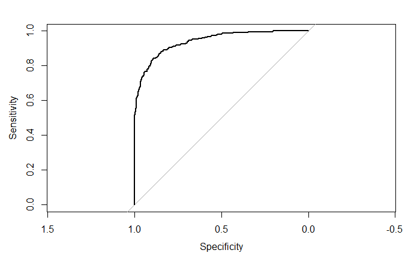

```r
roc_curve
```

```
Call:
roc.default(response = simulated_test$class, predictor = simulated_test$prob,     levels = rev(levels(simulated_test$class)))

Data: simulated_test$prob in 564 controls (simulated_test$class Class2) < 436 cases (simulated_test$class Class1).
Area under the curve: 0.9396
```

AUC is 0.94 which is quite high. The higher the AUC is, the better the model. I assume that when I’m deploying the model, I would use a threshold that maximises the tradeoff between sensitivity and specificity.

There is a problem with this. What if there is a curve that has a lower area but has a point where its threshold is better than the higher AUC.

ROC curves are used to maximise the trade-off between sensitivity and specificity. If you increase sensitivity, specificity will be reduced. If you increase sensitivity, a higher proportion of identified positives will be real positives. On the other hand, you get less true negatives, more false negatives. I’m way too tired for this.

Alright, how do I select the best threshold given a single ROC curve?

## Training models

You can specify ROC to be the evaluation criteria for the models, not the accuracy. However, even after that, the probability cutoff should be selected. How do you do that? Is it automatically selected? Do I need to select it myself?

You can also just tune your model for accuracy. BUT. What if you can also get much better results by additionally shifting class probability thresholds. You can do this by manually shifting the threshold. But this is post-cross validation. Therefore, wouldn’t it potentially lead to overfitting the model?

Ok, I read ahead a few chapters. The author uses a different holdout set of data to deal with class imbalance called the evaluation set. This comes after model training but before model testing. This is a tricky situation. In this case even though you cross-validated your model, due to the evaluation tuning, you have to test it on a separate test dataset. Interesting. I guess this is the price of dealing with data with extreme class imbalance.

The class-probability shifts definitely need to be used when the cost of a false positive is not the same as the cost of a false negative. It could just be reclassified manually. I will dig into this a bit deeper.